# Lecture 11: Binary IRT Models

Bayesian Psychometric Modeling

```r
# Install/Load Packages ===============================================================================================
if (!require(R2jags)) install.packages("R2jags")
```

```
## Linked to JAGS 4.3.0
```

```
## Loaded modules: basemod,bugs
```

```r
library(R2jags)

if (!require(CDM)) install.packages("CDM")
```

```
## ** CDM 7.3-17 (2019-03-18 18:33:40)
## ** Cognitive Diagnostic Models  **
```

```r
library(CDM)

if (!require(MASS)) install.packages("MASS")
library(MASS)
FSdata = fraction.subtraction.data
FSQmatrix = fraction.subtraction.qmatrix
```

## Item Response Models for Binary Data: Example Analyses

We will use the Tatsuoka (1984) fraction subtraction data for today’s examples. See DeCarlo (2011, p. 9) for the items: https://scholar.google.com/scholar?hl=en&as_sdt=0%2C36&q=l+decarlo+2011&btnG=.

First, we will treat these data as unidimensional to demonstrate unidimensional IRT models. We can use the syntax from the unidimensional CFA model as a start for modeling the 2PL model.This uses slope/intercept form, which we will change to discrimination/difficulty later. Also, we will use R2jags to make quick use of DIC for model comparisons.

**Also note: these analyses take an excessive amount of time to run. So, please follow along with the HTML file through class.**

### Model 1: Unidimensional 2PNO Model

```r
# model 1 specs:
nItems = ncol(FSdata)
```

```r
# marker item:
model01.function = function(){

  # measurement model specification
    for (person in 1:N){
      for (item in 1:I){
        X[person, item] ~ dbern(phi(mu[item] + lambda[item]*theta[person]))
      }
    }

  # prior distribution for the factor variance
    theta.precision ~ dgamma(theta.alpha.0, theta.beta.0)

  # saved parameters
    theta.variance <- 1/theta.precision

  # prior distributions for the factor:
    for (person in 1:N){
      theta[person] ~ dnorm(0, theta.precision)
      thetaS[person] <- theta[person]/theta.variance
    }

  # prior distributions for the measurement model mean/precision parameters
    for (item in 1:I){
      mu[item] ~ dnorm(mu.mean.0, mu.precision.0)
    }

  # prior distributions for the loadings (except the first loading, which is fixed to 1.0)
    lambda[1] <- 1
    for (item in 2:I){
      lambda[item] ~ dnorm(lambda.mean.0, lambda.precision.0)
    }

  # create standardized lambda
    lambdaS <- sqrt(theta.variance)*lambda

}
```

```r
# specification of prior values for measurement model parameters:
#   item intercepts
mu.mean.0 = 0
mu.variance.0 = 100
mu.precision.0 = 1 / mu.variance.0

#   Factor loadings -- these are the discriminations
lambda.mean.0 = 0
lambda.variance.0 = 100
lambda.precision.0 = 1 / lambda.variance.0

# unique variances -- these do not exist

# values for prior for factor variance (based on variance of marker item)
theta.df.0 = 1
theta.var.0 = 1
theta.alpha.0 = theta.df.0/2
theta.beta.0 = (theta.df.0*theta.var.0)/2


# next, create data for JAGS to use:
model01.data = list(
  N = nrow(FSdata),
  X = FSdata,
  I = nItems,
  mu.mean.0 = mu.mean.0,
  mu.precision.0 = mu.precision.0,
  lambda.mean.0 = lambda.mean.0,
  lambda.precision.0 = lambda.precision.0,
  theta.alpha.0 = theta.alpha.0,
  theta.beta.0 = theta.beta.0
)

model01.parameters = c("mu", "lambda",  "theta.variance", "theta", "thetaS", "lambdaS", "b")
```

```r
# for reproducable analyses
model01.seed = 06042019
```

Here, we will use the R2jags `jags.parallel()` function, which will run somewhat faster (one chain per core):

```r
model01.r2jags =  jags.parallel(
  data = model01.data,
  parameters.to.save = model01.parameters,
  model.file = model01.function,
  n.chains = 4,
  n.iter = 2000,
  n.thin = 1,
  n.burnin = 1000,
  n.cluster = 4,
  jags.seed = model01.seed
)
model01.r2jags
```

```
## Inference for Bugs model at "model01.function", fit using jags,
##  4 chains, each with 2000 iterations (first 1000 discarded)
##  n.sims = 4000 iterations saved
##                 mu.vect sd.vect     2.5%      25%      50%      75%
## lambda[1]         1.000   0.000    1.000    1.000    1.000    1.000
## lambda[2]         1.540   0.195    1.204    1.399    1.525    1.662
## lambda[3]         1.287   0.164    1.005    1.166    1.277    1.390
## lambda[4]         0.745   0.107    0.564    0.668    0.739    0.811
## lambda[5]         0.604   0.087    0.449    0.542    0.600    0.659
## lambda[6]         1.133   0.165    0.846    1.014    1.127    1.237
## lambda[7]         1.381   0.189    1.047    1.250    1.366    1.496
## lambda[8]         0.621   0.094    0.460    0.551    0.614    0.680
## lambda[9]         0.421   0.069    0.300    0.373    0.415    0.464
## lambda[10]        1.560   0.210    1.205    1.411    1.540    1.690
## lambda[11]        1.486   0.217    1.127    1.334    1.464    1.619
## lambda[12]        0.979   0.138    0.740    0.883    0.966    1.062
## lambda[13]        1.512   0.228    1.117    1.349    1.493    1.656
## lambda[14]        1.145   0.163    0.867    1.027    1.131    1.248
## lambda[15]        1.447   0.198    1.097    1.306    1.428    1.577
## lambda[16]        1.006   0.140    0.761    0.906    0.996    1.095
## lambda[17]        1.735   0.247    1.293    1.560    1.716    1.889
## lambda[18]        1.239   0.171    0.942    1.116    1.224    1.350
## lambda[19]        2.010   0.313    1.479    1.789    1.989    2.197
## lambda[20]        1.770   0.269    1.296    1.579    1.749    1.943
## lambdaS[1]        1.257   0.139    0.997    1.158    1.251    1.351
## lambdaS[2]        1.916   0.175    1.593    1.794    1.907    2.030
## lambdaS[3]        1.601   0.146    1.330    1.498    1.597    1.693
## lambdaS[4]        0.925   0.090    0.762    0.862    0.923    0.983
## lambdaS[5]        0.751   0.078    0.600    0.696    0.749    0.801
## lambdaS[6]        1.408   0.150    1.134    1.305    1.398    1.507
## lambdaS[7]        1.716   0.162    1.408    1.606    1.709    1.819
## lambdaS[8]        0.771   0.087    0.609    0.713    0.767    0.827
## lambdaS[9]        0.523   0.069    0.396    0.477    0.521    0.570
## lambdaS[10]       1.940   0.194    1.594    1.806    1.930    2.058
## lambdaS[11]       1.845   0.179    1.527    1.724    1.834    1.955
## lambdaS[12]       1.216   0.115    1.005    1.138    1.210    1.292
## lambdaS[13]       1.879   0.212    1.504    1.732    1.863    2.022
## lambdaS[14]       1.423   0.135    1.169    1.330    1.418    1.510
## lambdaS[15]       1.798   0.168    1.484    1.682    1.794    1.908
## lambdaS[16]       1.250   0.118    1.034    1.168    1.244    1.328
```

[output cut: 2225 more lines]

```
## thetaS[530]      -0.389 1.018   170
## thetaS[531]      -0.344 1.003  1000
## thetaS[532]      -0.789 1.017   200
## thetaS[533]       0.897 1.003   980
## thetaS[534]      -0.763 1.008   330
## thetaS[535]       0.838 1.004   650
## thetaS[536]       0.357 1.003   960
## deviance       7983.044 1.003  1100
##
## For each parameter, n.eff is a crude measure of effective sample size,
## and Rhat is the potential scale reduction factor (at convergence, Rhat=1).
##
## DIC info (using the rule, pD = var(deviance)/2)
## pD = 643.9 and DIC = 8554.0
## DIC is an estimate of expected predictive error (lower deviance is better).
```

```r
# printing only certain parameters
summary(mcmc(model01.r2jags$BUGSoutput$sims.matrix[,grep(x = colnames(model01.r2jags$BUGSoutput$sims.matrix), pattern = "lambda")]))
```

```
##
## Iterations = 1:4000
## Thinning interval = 1
## Number of chains = 1
## Sample size per chain = 4000
##
## 1. Empirical mean and standard deviation for each variable,
##    plus standard error of the mean:
##
##               Mean      SD Naive SE Time-series SE
## lambda[1]   1.0000 0.00000 0.000000       0.000000
## lambda[2]   1.5395 0.19473 0.003079       0.003079
## lambda[3]   1.2865 0.16409 0.002595       0.002595
## lambda[4]   0.7445 0.10686 0.001690       0.001690
## lambda[5]   0.6041 0.08739 0.001382       0.001382
## lambda[6]   1.1330 0.16490 0.002607       0.002607
## lambda[7]   1.3805 0.18859 0.002982       0.002982
## lambda[8]   0.6207 0.09444 0.001493       0.001493
## lambda[9]   0.4208 0.06912 0.001093       0.001145
## lambda[10]  1.5598 0.21037 0.003326       0.003326
## lambda[11]  1.4858 0.21700 0.003431       0.003431
## lambda[12]  0.9790 0.13820 0.002185       0.002185
## lambda[13]  1.5120 0.22767 0.003600       0.003600
## lambda[14]  1.1453 0.16278 0.002574       0.002574
## lambda[15]  1.4468 0.19818 0.003134       0.003134
## lambda[16]  1.0059 0.13996 0.002213       0.002213
## lambda[17]  1.7349 0.24693 0.003904       0.003904
## lambda[18]  1.2385 0.17106 0.002705       0.002705
## lambda[19]  2.0102 0.31303 0.004950       0.004950
## lambda[20]  1.7696 0.26854 0.004246       0.004246
## lambdaS[1]  1.2567 0.13935 0.002203       0.002203
## lambdaS[2]  1.9157 0.17544 0.002774       0.002774
## lambdaS[3]  1.6005 0.14558 0.002302       0.002020
## lambdaS[4]  0.9249 0.09020 0.001426       0.001426
## lambdaS[5]  0.7508 0.07825 0.001237       0.001237
## lambdaS[6]  1.4082 0.14963 0.002366       0.002366
## lambdaS[7]  1.7160 0.16187 0.002559       0.002559
## lambdaS[8]  0.7713 0.08673 0.001371       0.001371
## lambdaS[9]  0.5232 0.06892 0.001090       0.001090
## lambdaS[10] 1.9404 0.19409 0.003069       0.003069
```

[output cut: 39 more lines]

```
## lambdaS[6]  1.1341 1.3052 1.3978 1.5074 1.7061
## lambdaS[7]  1.4079 1.6059 1.7092 1.8186 2.0502
## lambdaS[8]  0.6090 0.7131 0.7674 0.8269 0.9494
## lambdaS[9]  0.3957 0.4766 0.5214 0.5695 0.6615
## lambdaS[10] 1.5938 1.8064 1.9298 2.0581 2.3627
## lambdaS[11] 1.5266 1.7241 1.8336 1.9553 2.2303
## lambdaS[12] 1.0049 1.1379 1.2102 1.2918 1.4573
## lambdaS[13] 1.5042 1.7324 1.8635 2.0216 2.3166
## lambdaS[14] 1.1691 1.3303 1.4179 1.5098 1.7009
## lambdaS[15] 1.4840 1.6821 1.7941 1.9081 2.1336
## lambdaS[16] 1.0342 1.1677 1.2441 1.3284 1.4978
## lambdaS[17] 1.7615 2.0086 2.1473 2.2954 2.5969
## lambdaS[18] 1.2796 1.4396 1.5314 1.6302 1.8351
## lambdaS[19] 1.9742 2.2797 2.4711 2.6898 3.1649
## lambdaS[20] 1.7671 2.0360 2.1816 2.3464 2.7050
```

```r
summary(mcmc(model01.r2jags$BUGSoutput$sims.matrix[,grep(x = colnames(model01.r2jags$BUGSoutput$sims.matrix), pattern = "mu")]))
```

```
##
## Iterations = 1:4000
## Thinning interval = 1
## Number of chains = 1
## Sample size per chain = 4000
##
## 1. Empirical mean and standard deviation for each variable,
##    plus standard error of the mean:
##
##            Mean      SD Naive SE Time-series SE
## mu[1]   0.06408 0.08917 0.001410       0.001410
## mu[2]   0.32214 0.12115 0.001915       0.001915
## mu[3]  -0.03137 0.10519 0.001663       0.001663
## mu[4]   0.09632 0.07398 0.001170       0.001170
## mu[5]   0.26030 0.06911 0.001093       0.001093
## mu[6]   1.41857 0.14207 0.002246       0.002246
## mu[7]  -0.61715 0.11784 0.001863       0.001945
## mu[8]   0.84541 0.07974 0.001261       0.001261
## mu[9]   0.42840 0.06327 0.001000       0.001052
## mu[10] -0.79225 0.14025 0.002218       0.002218
## mu[11] -0.22250 0.11940 0.001888       0.001888
## mu[12]  0.93691 0.10161 0.001607       0.001607
## mu[13] -1.27484 0.16691 0.002639       0.002639
## mu[14]  0.99354 0.11308 0.001788       0.001788
## mu[15] -0.35679 0.11768 0.001861       0.001861
## mu[16]  0.79036 0.09758 0.001543       0.001543
## mu[17] -0.54511 0.14007 0.002215       0.002215
## mu[18] -0.24609 0.10272 0.001624       0.001624
## mu[19] -1.52022 0.21917 0.003465       0.003234
## mu[20] -0.82719 0.15985 0.002527       0.002527
##
## 2. Quantiles for each variable:
##
##            2.5%       25%      50%      75%     97.5%
## mu[1]  -0.10956  0.005762  0.06457  0.12448  0.234352
## mu[2]   0.08684  0.241970  0.31875  0.40141  0.569328
## mu[3]  -0.24560 -0.101193 -0.03018  0.04035  0.170384
## mu[4]  -0.04999  0.045594  0.09672  0.14484  0.242281
## mu[5]   0.12391  0.213584  0.25972  0.30514  0.400644
## mu[6]   1.15412  1.322699  1.41119  1.51007  1.712144
## mu[7]  -0.85878 -0.692088 -0.61445 -0.53761 -0.393747
## mu[8]   0.69632  0.790333  0.84378  0.89770  1.005056
## mu[9]   0.30074  0.385485  0.42889  0.47077  0.553414
## mu[10] -1.08153 -0.882052 -0.79092 -0.69839 -0.529173
## mu[11] -0.45685 -0.301499 -0.22258 -0.14210  0.008955
## mu[12]  0.74839  0.867266  0.93276  1.00543  1.145106
## mu[13] -1.62136 -1.384000 -1.26619 -1.15928 -0.969061
## mu[14]  0.77939  0.915182  0.98999  1.06619  1.220323
## mu[15] -0.58877 -0.436072 -0.35550 -0.27662 -0.125807
## mu[16]  0.60833  0.724089  0.78749  0.85499  0.993036
## mu[17] -0.84207 -0.634052 -0.54048 -0.44968 -0.283723
## mu[18] -0.44977 -0.314089 -0.24560 -0.17786 -0.042298
## mu[19] -1.98598 -1.654615 -1.50484 -1.36952 -1.134154
## mu[20] -1.15607 -0.927429 -0.82246 -0.71768 -0.531378
```

```r
summary(mcmc(model01.r2jags$BUGSoutput$sims.matrix[,grep(x = colnames(model01.r2jags$BUGSoutput$sims.matrix), pattern = "theta.variance")]))
```

```
##
## Iterations = 1:4000
## Thinning interval = 1
## Number of chains = 1
## Sample size per chain = 4000
##
## 1. Empirical mean and standard deviation for each variable,
##    plus standard error of the mean:
##
##           Mean             SD       Naive SE Time-series SE
##       1.598648       0.354224       0.005601       0.005601
##
## 2. Quantiles for each variable:
##
##   2.5%    25%    50%    75%  97.5%
## 0.9943 1.3411 1.5647 1.8264 2.3444
```

Now, let’s look at model fit. We will have to use a slightly different version of the syntax from before:

```r
# list number of simulated data sets
nSimulatedDataSets = 5000

# create one large matrix of posterior values
model01.Posterior.all = model01.r2jags$BUGSoutput$sims.matrix
dim(model01.Posterior.all)
```

```
## [1] 4000 1134
```

```r
# determine columns of posterior that go into each model matrix
# colnames(model01.Posterior.all)
muCols = grep(x = colnames(model01.Posterior.all), pattern = "mu")
lambdaCols = grep(x = colnames(model01.Posterior.all), pattern = "lambda\\[")
varCol = grep(x = colnames(model01.Posterior.all), pattern = "theta.variance")

# save simulated covariances:
simCovModel01 = matrix(data = NA, nrow = nSimulatedDataSets, ncol = nItems*nItems)

# loop through data sets (can be sped up with functions and lapply)
pb = txtProgressBar()
sim = 1
for (sim in 1:nSimulatedDataSets){

  # draw sample from one iteration of posterior chain
  iternum = sample(x = 1:nrow(model01.Posterior.all), size = 1, replace = TRUE)

  # get parameters for that sample: put into factor model matrices for easier generation of data
  mu = matrix(data = model01.Posterior.all[iternum, muCols], ncol = 1)
  lambda = matrix(data = model01.Posterior.all[iternum, lambdaCols], ncol = 1)
  varTheta = model01.Posterior.all[iternum, varCol]

  # generate sample of thetas from theta distribution
  theta = matrix(data = rnorm(n = nrow(FSdata), mean = 0, sd = sqrt(varTheta)), nrow = nrow(FSdata), ncol = 1)

  # calculate predicted probits:
  probits = matrix(data = 1, nrow = nrow(FSdata), ncol = 1) %*% t(mu) + theta %*% t(lambda)

  simData = probits
  i=1
  for (i in 1:ncol(probits)){
    simData[,i] = rbinom(n = nrow(probits), size = 1, prob = pnorm(q = probits[,i]) )
  }

  # calculate the value of SRMR using simulated data's covariance matrix and observed covariance matrix
  simCov = cov(simData)
  simCovModel01[sim,] = c(cov(simData))

  setTxtProgressBar(pb = pb, value = sim/nSimulatedDataSets)
}
close(pb)
```

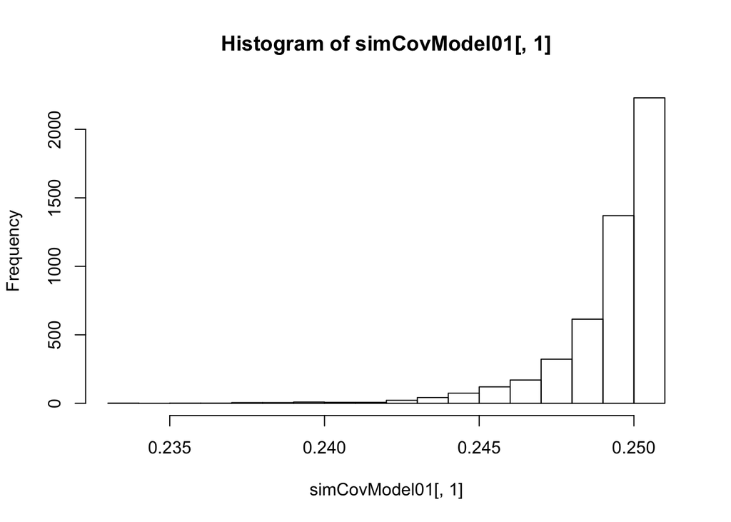

```r
# label values of simCor to ensure we have the right comparison
covNames = NULL
for (i in 1:ncol(simData)){
  for (j in 1:ncol(simData)){
    covNames = c(covNames, paste0("cov", i, "." , j))
  }
}
colnames(simCovModel01) = covNames

# show how one correlation compares to distribution of simulated correlations
dataCov = cov(FSdata)
hist(simCovModel01[,1])
```

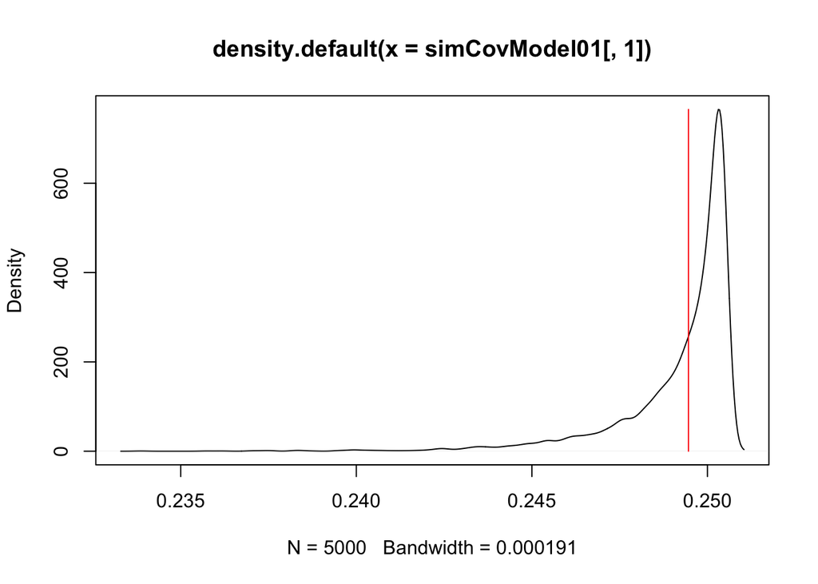

```r
plot(density(simCovModel01[,1]))
lines(x = c(dataCov[1,1], dataCov[1,1]), y = c(0, max(density(simCovModel01[,1])$y)), col = 2)
```

```r
quantile(simCovModel01[,1])
```

```
##        0%       25%       50%       75%      100%
## 0.2338646 0.2487795 0.2498779 0.2503417 0.2504673
```

```r
mean(simCovModel01[,1])
```

```
## [1] 0.2492233
```

```r
dataCov[1,1]
```

```
## [1] 0.2494595
```

```r
# create quantiles of correlations to see where each observed correlation falls
covQuantiles01 = NULL

# compute the quantiles of the observed correlations:

col = 1
for (i in 1:ncol(simData)){
  for (j in 1:ncol(simData)){
    # get empirical CDF of simulated correlation distribution
    covEcdf = ecdf(simCovModel01[,col])
    covQuantiles01 = rbind(covQuantiles01, c(i, j, summary(covEcdf), dataCov[i,j], covEcdf(dataCov[i,j])))

    col = col + 1
  }
}
colnames(covQuantiles01)[1:2] = c("Item 1", "Item 2")
colnames(covQuantiles01)[9:10] = c("ObsCor", "CorPctile")
covQuantiles01[which(covQuantiles01[,10] > .975 | covQuantiles01[,10] < .025),]
```

```
##       Item 1 Item 2         Min.    1st Qu.     Median       Mean
##  [1,]      1      2  0.075059283 0.11031350 0.11934021 0.11929480
##  [2,]      1      3  0.072660064 0.10494141 0.11413377 0.11403848
##  [3,]      1      5  0.028923141 0.06623483 0.07539406 0.07528510
##  [4,]      1      6  0.038003906 0.06591226 0.07391198 0.07393454
##  [5,]      2      1  0.075059283 0.11031350 0.11934021 0.11929480
##  [6,]      2      3  0.093241735 0.12425547 0.13256730 0.13248922
##  [7,]      2      5  0.037927186 0.07757707 0.08671014 0.08648109
##  [8,]      3      1  0.072660064 0.10494141 0.11413377 0.11403848
##  [9,]      3      2  0.093241735 0.12425547 0.13256730 0.13248922
## [10,]      3     20  0.085060678 0.12070721 0.12898591 0.12890752
## [11,]      4      5  0.023406333 0.05582892 0.06479286 0.06488424
## [12,]      4      8  0.009101688 0.04522946 0.05339308 0.05348435
## [13,]      4      9  0.004261403 0.03783477 0.04673943 0.04674202
## [14,]      4     10  0.049508300 0.08438590 0.09351723 0.09334943
```

[output cut: 107 more lines]

### Creating Standardized Estimates

Our previous example used a standardized mean/marker item variance scale identification technique. We will see with multivariate IRT models, this will be a common method of identification. But, we can convert these results to one where the theta variance is set to one with a bit of math:

First, the kernel of the model must be the same after standardization. That is, $\mu_i + \lambda_i \theta_p = \mu_i^S + \lambda_i^S \theta_i^S$ – meaning that item response probabilities are invariant after transformation. As $\theta_p$ has mean $0$ and variance $\sigma^2_\theta$, to standardize it, we can divide by $\sigma_\theta$:

$$\theta_p^S = \frac{\theta_p}{\sigma_\theta}$$

Now, $\theta_p^S$ has variance $1$. To make the item response probabilities correspond, we must transform $\lambda_i$ similarly. We can do so by taking:

$$\lambda^S = \sigma_\theta \lambda_p$$

As this term cancels the variance transformation for $\theta_p$, we are left with:

$$\mu_i^S = \mu_i$$

In the model syntax above, you can see how this is computed for `lambdaS` and `thetaS`.

### Transforming from Slope/Intercept to Discrimination/Difficulty

The IRT model core $a_i\left(\theta_p - b_i \right)$ can be reparameterized as

$$\mu_i + \lambda_i \theta_i,$$

Which comes from multiplying $a_i$ through $\left(\theta_p - b_i \right)$:

$$a_i\left(\theta_p - b_i \right) = -a_ib_i + a_i\theta_i = \mu_i + \lambda_i\theta_i$$

Where,

- $\lambda_i = a_i$
- $\mu_i = -a_ib_i$, leading to $b_i = -\frac{\mu_i}{a_i} = -\frac{\mu_i}{\lambda_i}$

Finally, we can transform our standardized parameters to values are in the Discrimination/Difficulty parameterization (which often uses standardized $\theta_p$). To do this, all we need to create is the difficulty parameter as the discrimination parameter is equal to the standardized loading. This is not in the model syntax as JAGS has an issue with running this code. So, we can do this with the posterior distribution:

```r
muCols = grep(x = colnames(model01.Posterior.all), pattern = "mu")
lambdaCols = grep(x = colnames(model01.Posterior.all), pattern = "lambda\\[")
varCol = grep(x = colnames(model01.Posterior.all), pattern = "theta.variance")

b = matrix(data = NA, nrow = nrow(model01.Posterior.all), ncol = nItems)

for (rep in 1:nrow(model01.Posterior.all)){
  mu = matrix(data = model01.Posterior.all[rep, muCols], ncol = 1)
  lambda = matrix(data = model01.Posterior.all[rep, lambdaCols], ncol = 1)
  varTheta = model01.Posterior.all[rep, varCol]
  for (item in 1:nItems){
    b[rep,item] = -1*mu[item]/(lambda[item]*sqrt(varTheta))
  }
}

summary(mcmc(b))
```

```
##
## Iterations = 1:4000
## Thinning interval = 1
## Number of chains = 1
## Sample size per chain = 4000
##
## 1. Empirical mean and standard deviation for each variable,
##    plus standard error of the mean:
##
##           Mean      SD  Naive SE Time-series SE
##  [1,] -0.05218 0.07199 0.0011383      0.0011383
##  [2,] -0.16902 0.06357 0.0010052      0.0010052
##  [3,]  0.01885 0.06556 0.0010366      0.0010366
##  [4,] -0.10501 0.08105 0.0012816      0.0012816
##  [5,] -0.34942 0.09586 0.0015157      0.0015157
##  [6,] -1.01216 0.09168 0.0014496      0.0014496
##  [7,]  0.36023 0.06328 0.0010006      0.0010006
##  [8,] -1.10609 0.13329 0.0021074      0.0020035
##  [9,] -0.83120 0.15492 0.0024495      0.0024495
## [10,]  0.40876 0.06269 0.0009912      0.0009912
## [11,]  0.12038 0.06329 0.0010006      0.0010006
## [12,] -0.77419 0.08734 0.0013810      0.0013810
## [13,]  0.68032 0.06821 0.0010784      0.0011096
## [14,] -0.70147 0.07937 0.0012550      0.0012550
## [15,]  0.19866 0.06368 0.0010069      0.0010013
## [16,] -0.63553 0.08135 0.0012862      0.0012623
## [17,]  0.25288 0.05990 0.0009470      0.0009470
## [18,]  0.15997 0.06555 0.0010364      0.0010364
## [19,]  0.60971 0.06185 0.0009779      0.0009779
## [20,]  0.37654 0.06093 0.0009634      0.0009634
##
## 2. Quantiles for each variable:
##
##            2.5%      25%      50%       75%    97.5%
## var1  -0.191067 -0.10066 -0.05182 -0.004798  0.08822
## var2  -0.298795 -0.21087 -0.16781 -0.126442 -0.04582
## var3  -0.108836 -0.02494  0.01834  0.062867  0.14782
## var4  -0.266316 -0.15835 -0.10481 -0.049637  0.05337
## var5  -0.549300 -0.41121 -0.34791 -0.286375 -0.16280
## var6  -1.198866 -1.07274 -1.00941 -0.949161 -0.83992
## var7   0.234358  0.31770  0.35924  0.403542  0.48610
## var8  -1.385015 -1.18987 -1.09556 -1.014163 -0.86606
## var9  -1.158443 -0.93227 -0.81933 -0.723043 -0.55723
## var10  0.284776  0.36623  0.41014  0.451681  0.52968
## var11 -0.004849  0.07787  0.12059  0.163863  0.24210
## var12 -0.950184 -0.83055 -0.77190 -0.713136 -0.60633
## var13  0.550789  0.63504  0.68003  0.725419  0.81430
## var14 -0.864681 -0.75314 -0.69843 -0.648384 -0.55479
## var15  0.073170  0.15607  0.19909  0.242881  0.31964
## var16 -0.795797 -0.69062 -0.63207 -0.579399 -0.48134
## var17  0.136305  0.21243  0.25299  0.292523  0.36952
## var18  0.028539  0.11752  0.15950  0.203733  0.28940
## var19  0.492291  0.56704  0.60861  0.652753  0.72830
## var20  0.252415  0.33661  0.37699  0.417727  0.49275
```

Of note, one can always convert one model parameterization to the other. Depending on prior selection, it is not guaranteed that the posterior distributions will be identical. Model 2 shows this same analysis in discrimination/difficulty form with a standardized factor variance:

## Model 2: 2PNO/Standardized Theta/Discrimination/Difficulty Parameterization

```r
# marker item:
model02.function = function(){

  # measurement model specification
    for (person in 1:N){
      for (item in 1:I){
        X[person, item] ~ dbern(phi(a[item]*(theta[person]-b[item])))
      }
    }

  # prior distributions for the factor:
    for (person in 1:N){
      theta[person] ~ dnorm(0, 1)
    }

  # prior distributions for the measurement model parameters
    for (item in 1:I){
      a[item] ~ dlnorm(a.mean.0, a.precision.0)
      b[item] ~ dnorm(b.mean.0, b.precision.0)
      mu[item] <- -1*a[item]*b[item]
    }

}
```

```r
# specification of prior values for measurement model parameters:
#   item intercepts
a.mean.0 = 0
a.variance.0 = 100
a.precision.0 = 1 / a.variance.0

#   Factor loadings -- these are the discriminations
b.mean.0 = 0
b.variance.0 = 100
b.precision.0 = 1 / b.variance.0

# next, create data for JAGS to use:
model02.data = list(
  N = nrow(FSdata),
  X = FSdata,
  I = nItems,
  a.mean.0 = a.mean.0,
  a.precision.0 = a.precision.0,
  b.mean.0 = b.mean.0,
  b.precision.0 = b.precision.0
)

model02.parameters = c("mu", "a", "theta", "b")
```

```r
# for reproducable analyses
model02.seed = 06042019+1
```

Here, we will use the R2jags `jags.parallel()` function, which will run somewhat faster (one chain per core):

```r
model02.r2jags =  jags.parallel(
  data = model02.data,
  parameters.to.save = model02.parameters,
  model.file = model02.function,
  n.chains = 4,
  n.iter = 2000,
  n.thin = 1,
  n.burnin = 1000,
  n.cluster = 4,
  jags.seed = model02.seed
)
model02.r2jags
```

```
## Inference for Bugs model at "model02.function", fit using jags,
##  4 chains, each with 2000 iterations (first 1000 discarded)
##  n.sims = 4000 iterations saved
##             mu.vect sd.vect     2.5%      25%      50%      75%    97.5%
## a[1]          1.433   0.131    1.188    1.344    1.427    1.519    1.704
## a[2]          1.873   0.174    1.557    1.752    1.864    1.986    2.233
## a[3]          1.561   0.146    1.297    1.461    1.554    1.653    1.865
## a[4]          0.891   0.085    0.735    0.831    0.890    0.948    1.066
## a[5]          0.725   0.076    0.575    0.673    0.724    0.778    0.873
## a[6]          1.352   0.139    1.084    1.259    1.346    1.441    1.628
## a[7]          1.655   0.164    1.355    1.540    1.650    1.762    2.008
## a[8]          0.741   0.081    0.588    0.685    0.739    0.796    0.905
## a[9]          0.499   0.070    0.366    0.452    0.498    0.544    0.641
## a[10]         1.865   0.189    1.521    1.734    1.857    1.984    2.259
## a[11]         1.774   0.160    1.479    1.664    1.765    1.880    2.101
## a[12]         1.177   0.115    0.957    1.102    1.173    1.248    1.422
## a[13]         1.810   0.210    1.442    1.663    1.797    1.940    2.256
## a[14]         1.381   0.134    1.135    1.287    1.373    1.467    1.663
## a[15]         1.733   0.170    1.418    1.615    1.723    1.843    2.089
## a[16]         1.211   0.114    0.990    1.133    1.209    1.291    1.430
## a[17]         2.073   0.211    1.691    1.927    2.064    2.209    2.506
## a[18]         1.482   0.142    1.225    1.382    1.477    1.576    1.770
## a[19]         2.366   0.298    1.835    2.165    2.339    2.548    3.002
## a[20]         2.095   0.227    1.680    1.937    2.084    2.242    2.578
## b[1]         -0.040   0.067   -0.172   -0.084   -0.040    0.005    0.093
## b[2]         -0.174   0.062   -0.299   -0.214   -0.173   -0.132   -0.054
## b[3]          0.019   0.064   -0.107   -0.025    0.018    0.061    0.147
## b[4]         -0.110   0.082   -0.271   -0.164   -0.109   -0.056    0.050
## b[5]         -0.362   0.099   -0.559   -0.428   -0.360   -0.294   -0.179
## b[6]         -1.038   0.092   -1.237   -1.096   -1.033   -0.975   -0.871
## b[7]          0.371   0.065    0.245    0.326    0.371    0.414    0.497
## b[8]         -1.141   0.134   -1.430   -1.226   -1.133   -1.047   -0.896
## b[9]         -0.864   0.168   -1.227   -0.964   -0.851   -0.747   -0.570
## b[10]         0.417   0.061    0.294    0.376    0.418    0.458    0.534
## b[11]         0.121   0.062    0.001    0.080    0.121    0.163    0.242
## b[12]        -0.796   0.089   -0.980   -0.854   -0.792   -0.737   -0.631
## b[13]         0.696   0.067    0.567    0.651    0.695    0.739    0.829
## b[14]        -0.721   0.079   -0.884   -0.772   -0.719   -0.668   -0.571
## b[15]         0.207   0.061    0.091    0.165    0.207    0.249    0.325
## b[16]        -0.651   0.081   -0.817   -0.705   -0.649   -0.595   -0.497
```

[output cut: 1151 more lines]

```
## theta[530] 1.005   500
## theta[531] 1.004   830
## theta[532] 1.004   740
## theta[533] 1.001  4000
## theta[534] 1.005   860
## theta[535] 1.001  4000
## theta[536] 1.001  2500
## deviance   1.001  4000
##
## For each parameter, n.eff is a crude measure of effective sample size,
## and Rhat is the potential scale reduction factor (at convergence, Rhat=1).
##
## DIC info (using the rule, pD = var(deviance)/2)
## pD = 623.9 and DIC = 8536.0
## DIC is an estimate of expected predictive error (lower deviance is better).
```

As Model 2 has a different posterior distribution than Model 1 (even only slightly), Model 2 needs its own goodness of fit statistics:

```r
# list number of simulated data sets
nSimulatedDataSets = 5000

# create one large matrix of posterior values
model02.Posterior.all = model02.r2jags$BUGSoutput$sims.matrix
dim(model02.Posterior.all)
```

```
## [1] 4000  597
```

```r
# determine columns of posterior that go into each model matrix

aCols = 1:20
bCols = grep(x = colnames(model02.Posterior.all), pattern = "b\\[")

# save simulated covariances:
simCovModel02 = matrix(data = NA, nrow = nSimulatedDataSets, ncol = nItems*nItems)

# loop through data sets (can be sped up with functions and lapply)
pb = txtProgressBar()
sim = 1
for (sim in 1:nSimulatedDataSets){

  # draw sample from one iteration of posterior chain
  iternum = sample(x = 1:nrow(model02.Posterior.all), size = 1, replace = TRUE)

  # get parameters for that sample: put into factor model matrices for easier generation of data
  a = matrix(data = model02.Posterior.all[iternum, aCols], ncol = 1)
  b = matrix(data = model02.Posterior.all[iternum, bCols], ncol = 1)
  mu = -1*a*b

  # generate sample of thetas from theta distribution
  theta = matrix(data = rnorm(n = nrow(FSdata), mean = 0, sd = 1), nrow = nrow(FSdata), ncol = 1)

  # calculate predicted probits:
  probits = matrix(data = 1, nrow = nrow(FSdata), ncol = 1) %*% t(mu) + theta %*% t(a)

  simData = probits
  i=1
  for (i in 1:ncol(probits)){
    simData[,i] = rbinom(n = nrow(probits), size = 1, prob = pnorm(q = probits[,i]) )
  }

  # calculate the value of SRMR using simulated data's covariance matrix and observed covariance matrix
  simCov = cov(simData)
  simCovModel02[sim,] = c(cov(simData))

  setTxtProgressBar(pb = pb, value = sim/nSimulatedDataSets)
}
close(pb)
```

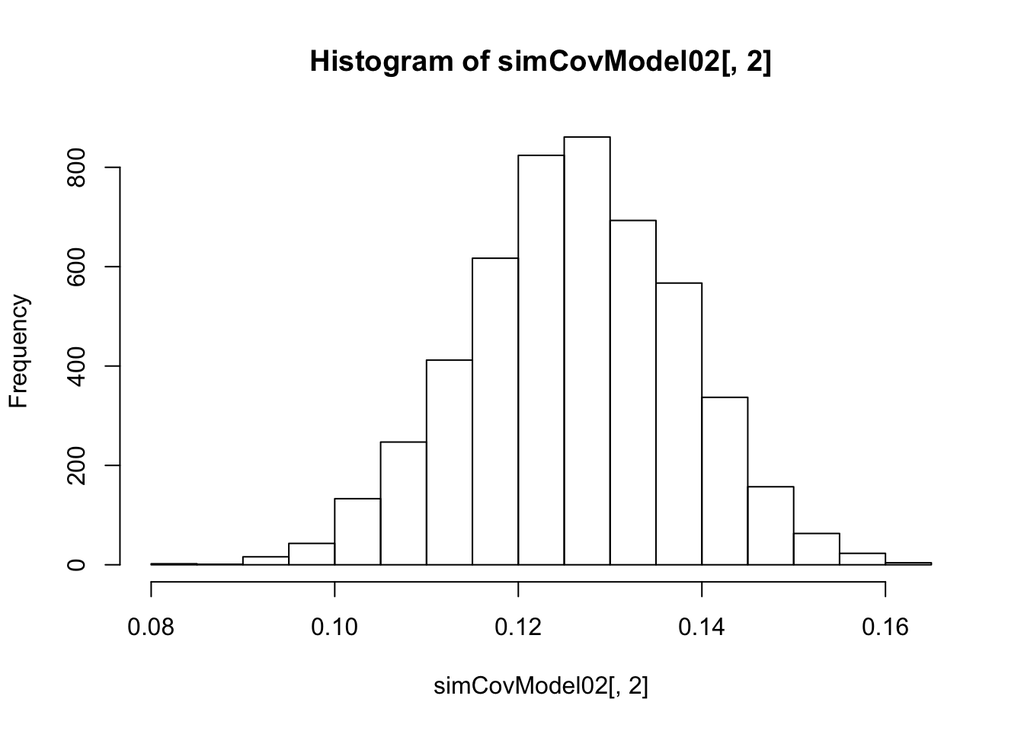

```r
# label values of simCor to ensure we have the right comparison
covNames = NULL
for (i in 1:ncol(simData)){
  for (j in 1:ncol(simData)){
    covNames = c(covNames, paste0("cov", i, "." , j))
  }
}
colnames(simCovModel02) = covNames

# show how one correlation compares to distribution of simulated correlations
dataCov = cov(FSdata)
hist(simCovModel02[,2])
```

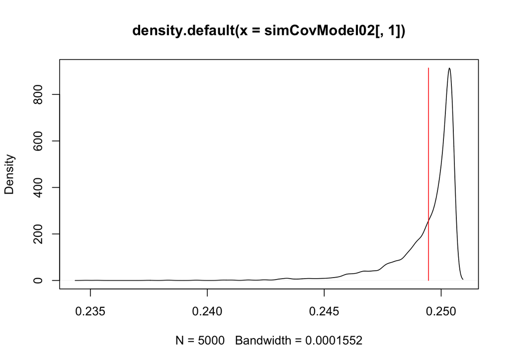

```r
plot(density(simCovModel02[,1]))
lines(x = c(dataCov[1,1], dataCov[1,1]), y = c(0, max(density(simCovModel02[,1])$y)), col = 2)
```

```r
quantile(simCovModel02[,1])
```

```
##        0%       25%       50%       75%      100%
## 0.2348131 0.2490724 0.2499651 0.2503417 0.2504673
```

```r
mean(simCovModel02[,1])
```

```
## [1] 0.2494026
```

```r
dataCov[1,1]
```

```
## [1] 0.2494595
```

```r
# create quantiles of correlations to see where each observed correlation falls
covQuantiles02 = NULL

# compute the quantiles of the observed correlations:

col = 1
for (i in 1:ncol(simData)){
  for (j in 1:ncol(simData)){
    # get empirical CDF of simulated correlation distribution
    covEcdf = ecdf(simCovModel02[,col])
    covQuantiles02 = rbind(covQuantiles02, c(i, j, summary(covEcdf), dataCov[i,j], covEcdf(dataCov[i,j])))

    col = col + 1
  }
}
colnames(covQuantiles02)[1:2] = c("Item 1", "Item 2")
colnames(covQuantiles02)[9:10] = c("ObsCor", "CorPctile")
covQuantiles02[which(covQuantiles02[,10] > .975 | covQuantiles02[,10] < .025),]
```

```
##       Item 1 Item 2         Min.    1st Qu.     Median       Mean
##  [1,]      1      2  0.080520296 0.11761055 0.12602525 0.12606159
##  [2,]      1      3  0.076754080 0.11159855 0.12045613 0.12018939
##  [3,]      1      5  0.030767890 0.06815979 0.07775840 0.07759450
##  [4,]      2      1  0.080520296 0.11761055 0.12602525 0.12606159
##  [5,]      2      3  0.080394755 0.12150579 0.12997629 0.12978974
##  [6,]      2      5  0.036846143 0.07442112 0.08397963 0.08363100
##  [7,]      3      1  0.076754080 0.11159855 0.12045613 0.12018939
##  [8,]      3      2  0.080394755 0.12150579 0.12997629 0.12978974
##  [9,]      3      5  0.026593667 0.07052588 0.07969033 0.07970690
## [10,]      3     20  0.085590738 0.11770819 0.12595202 0.12591373
## [11,]      4      8  0.010737202 0.04254429 0.05082299 0.05067106
## [12,]      4      9  0.002301576 0.03535186 0.04412924 0.04406799
## [13,]      4     10  0.051516948 0.08151590 0.09017994 0.09016312
## [14,]      4     11  0.053563956 0.08769616 0.09621112 0.09630804
```

[output cut: 123 more lines]

### Estimation of the 3PNO Model

We can now estimate a 3PNO model to compare model fit with that of the 2PNO:

```r
# marker item:
model03.function = function(){

  # measurement model specification
    for (person in 1:N){
      for (item in 1:I){
        X[person, item] ~ dbern(c[item]+(1-c[item])*phi(a[item]*(theta[person]-b[item])))
      }
    }

  # prior distributions for the factor:
    for (person in 1:N){
      theta[person] ~ dnorm(0, 1)
    }

  # prior distributions for the measurement model parameters
    for (item in 1:I){
      a[item] ~ dlnorm(a.mean.0, a.precision.0)
      b[item] ~ dnorm(b.mean.0, b.precision.0)
      c[item] ~ dbeta(c.a.0, c.b.0)
    }

}
```

```r
# specification of prior values for measurement model parameters:
a.mean.0 = 0
a.variance.0 = 100
a.precision.0 = 1 / a.variance.0

b.mean.0 = 0
b.variance.0 = 100
b.precision.0 = 1 / b.variance.0

c.a.0 = 1
c.b.0 = 1

# next, create data for JAGS to use:
model03.data = list(
  N = nrow(FSdata),
  X = FSdata,
  I = nItems,
  a.mean.0 = a.mean.0,
  a.precision.0 = a.precision.0,
  b.mean.0 = b.mean.0,
  b.precision.0 = b.precision.0,
  c.a.0 = c.a.0,
  c.b.0 = c.b.0
)

model03.parameters = c("a", "theta", "b", "c")
```

```r
# for reproducable analyses
model03.seed = 06042019+3
```

Here, we will use the R2jags `jags.parallel()` function, which will run somewhat faster (one chain per core):

```r
model03.r2jags =  jags.parallel(
  data = model03.data,
  parameters.to.save = model03.parameters,
  model.file = model03.function,
  n.chains = 4,
  n.iter = 2000,
  n.thin = 1,
  n.burnin = 1000,
  n.cluster = 4,
  jags.seed = model03.seed
)
model03.r2jags
```

```
## Inference for Bugs model at "model03.function", fit using jags,
##  4 chains, each with 2000 iterations (first 1000 discarded)
##  n.sims = 4000 iterations saved
##             mu.vect sd.vect     2.5%      25%      50%      75%    97.5%
## a[1]          1.490   0.136    1.237    1.394    1.485    1.580    1.767
## a[2]          1.930   0.192    1.577    1.797    1.922    2.052    2.331
## a[3]          1.631   0.155    1.342    1.522    1.625    1.737    1.939
## a[4]          2.541   0.394    1.875    2.270    2.504    2.757    3.418
## a[5]          1.331   0.315    0.843    1.105    1.288    1.514    2.032
## a[6]          1.364   0.139    1.109    1.266    1.355    1.457    1.647
## a[7]          1.828   0.190    1.478    1.696    1.820    1.954    2.223
## a[8]          1.643   0.378    0.979    1.372    1.614    1.883    2.461
## a[9]          0.807   0.334    0.455    0.593    0.722    0.919    1.806
## a[10]         2.276   0.265    1.805    2.087    2.271    2.445    2.839
## a[11]         3.575   0.657    2.529    3.120    3.500    3.916    5.102
## a[12]         1.197   0.117    0.983    1.115    1.193    1.276    1.440
## a[13]         1.994   0.249    1.552    1.820    1.975    2.155    2.503
## a[14]         1.402   0.131    1.159    1.311    1.398    1.488    1.675
## a[15]         2.066   0.238    1.644    1.901    2.052    2.218    2.577
## a[16]         1.226   0.117    1.009    1.144    1.223    1.303    1.468
## a[17]         2.778   0.464    2.081    2.460    2.713    3.018    3.878
## a[18]         1.624   0.162    1.327    1.511    1.615    1.730    1.952
## a[19]         2.705   0.360    2.079    2.463    2.670    2.919    3.499
## a[20]         2.720   0.416    2.013    2.429    2.675    2.966    3.669
## b[1]          0.020   0.067   -0.115   -0.026    0.021    0.065    0.151
## b[2]         -0.094   0.064   -0.216   -0.138   -0.095   -0.051    0.036
## b[3]          0.078   0.067   -0.050    0.032    0.077    0.124    0.207
## b[4]          0.367   0.068    0.239    0.322    0.365    0.409    0.510
## b[5]          0.242   0.159   -0.104    0.144    0.254    0.352    0.527
## b[6]         -0.985   0.099   -1.195   -1.048   -0.984   -0.922   -0.789
## b[7]          0.409   0.062    0.293    0.368    0.406    0.449    0.537
## b[8]         -0.043   0.188   -0.484   -0.140   -0.019    0.084    0.249
## b[9]         -0.096   0.427   -0.890   -0.437   -0.074    0.245    0.642
## b[10]         0.466   0.059    0.355    0.425    0.465    0.505    0.583
## b[11]         0.317   0.061    0.198    0.278    0.318    0.359    0.433
## b[12]        -0.726   0.097   -0.917   -0.792   -0.729   -0.660   -0.536
## b[13]         0.703   0.064    0.583    0.659    0.701    0.745    0.834
## b[14]        -0.655   0.084   -0.818   -0.711   -0.656   -0.600   -0.489
## b[15]         0.290   0.063    0.166    0.249    0.289    0.331    0.414
## b[16]        -0.585   0.089   -0.769   -0.643   -0.585   -0.524   -0.414
```

[output cut: 1151 more lines]

```
## theta[530] 1.001  3900
## theta[531] 1.001  3700
## theta[532] 1.003  1100
## theta[533] 1.018   230
## theta[534] 1.005  1200
## theta[535] 1.006   430
## theta[536] 1.005   530
## deviance   1.010   280
##
## For each parameter, n.eff is a crude measure of effective sample size,
## and Rhat is the potential scale reduction factor (at convergence, Rhat=1).
##
## DIC info (using the rule, pD = var(deviance)/2)
## pD = 774.4 and DIC = 8567.8
## DIC is an estimate of expected predictive error (lower deviance is better).
```

As Model 3 is very different from Models 1 and 2, we need still more goodness of fit checking:

```r
# list number of simulated data sets
nSimulatedDataSets = 5000

# create one large matrix of posterior values
model03.Posterior.all = model03.r2jags$BUGSoutput$sims.matrix
dim(model03.Posterior.all)
```

```
## [1] 4000  597
```

```r
# determine columns of posterior that go into each model matrix

aCols = 1:20
bCols = grep(x = colnames(model03.Posterior.all), pattern = "b\\[")
cCols = grep(x = colnames(model03.Posterior.all), pattern = "c\\[")

# save simulated covariances:
simCovModel03 = matrix(data = NA, nrow = nSimulatedDataSets, ncol = nItems*nItems)

# loop through data sets (can be sped up with functions and lapply)
pb = txtProgressBar()
sim = 1
for (sim in 1:nSimulatedDataSets){

  # draw sample from one iteration of posterior chain
  iternum = sample(x = 1:nrow(model03.Posterior.all), size = 1, replace = TRUE)

  # get parameters for that sample: put into factor model matrices for easier generation of data
  a = matrix(data = model03.Posterior.all[iternum, aCols], ncol = 1)
  b = matrix(data = model03.Posterior.all[iternum, bCols], ncol = 1)
  c = matrix(data = model03.Posterior.all[iternum, cCols], ncol = 1)
  mu = -1*a*b

  # generate sample of thetas from theta distribution
  theta = matrix(data = rnorm(n = nrow(FSdata), mean = 0, sd = 1), nrow = nrow(FSdata), ncol = 1)

  # calculate predicted probits:
  probits = matrix(data = 1, nrow = nrow(FSdata), ncol = 1) %*% t(mu) + theta %*% t(a)

  simData = probits
  i=1
  for (i in 1:ncol(probits)){
    probits[,i] =c[i]+(1-c[i])* pnorm(probits[,i])
    simData[,i] = rbinom(n = nrow(probits), size = 1, prob = probits )
  }

  # calculate the value of SRMR using simulated data's covariance matrix and observed covariance matrix
  simCov = cov(simData)
  simCovModel03[sim,] = c(cov(simData))

  setTxtProgressBar(pb = pb, value = sim/nSimulatedDataSets)
}
close(pb)
```

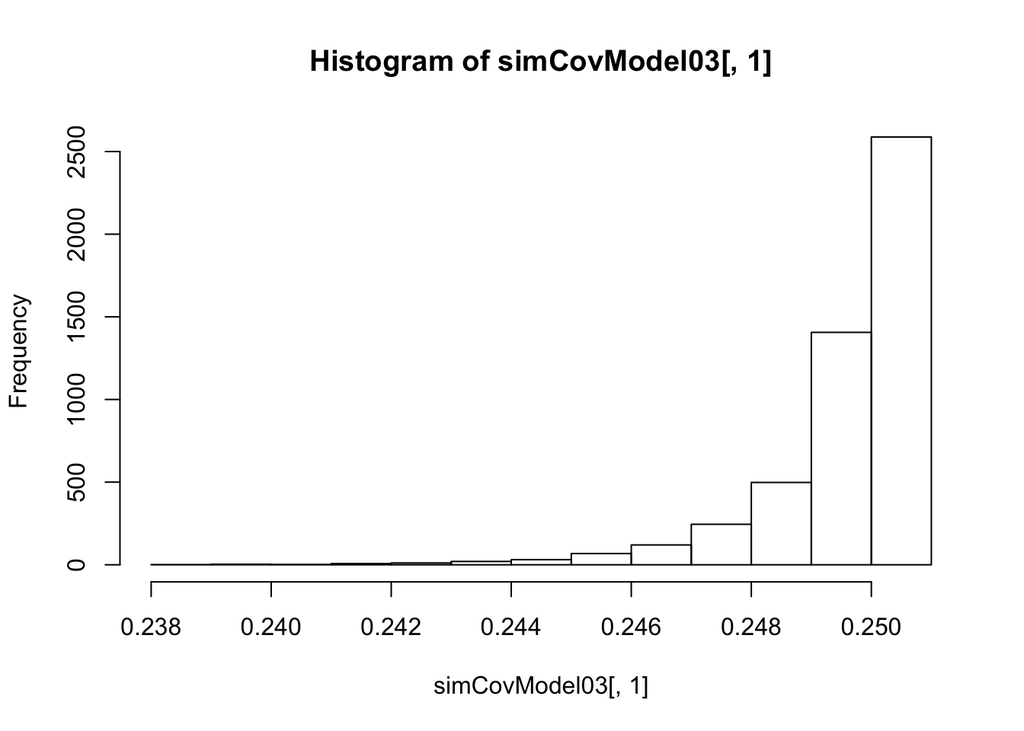

```r
# label values of simCor to ensure we have the right comparison
covNames = NULL
for (i in 1:ncol(simData)){
  for (j in 1:ncol(simData)){
    covNames = c(covNames, paste0("cov", i, "." , j))
  }
}
colnames(simCovModel03) = covNames

# show how one correlation compares to distribution of simulated correlations
dataCov = cov(FSdata)
hist(simCovModel03[,1])
```

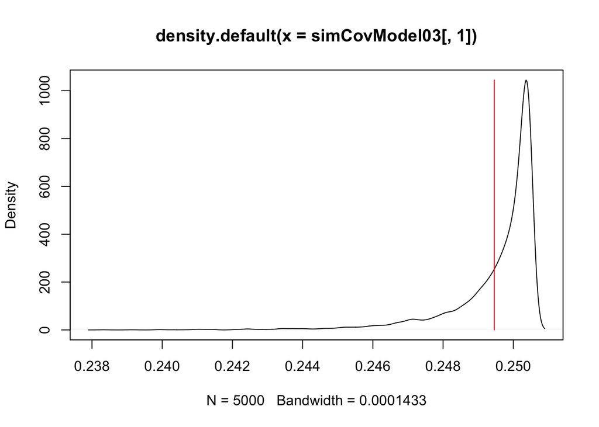

```r
plot(density(simCovModel03[,1]))
lines(x = c(dataCov[1,1], dataCov[1,1]), y = c(0, max(density(simCovModel03[,1])$y)), col = 2)
```

```r
quantile(simCovModel03[,1])
```

```
##        0%       25%       50%       75%      100%
## 0.2383282 0.2492084 0.2500453 0.2503801 0.2504673
```

```r
mean(simCovModel03[,1])
```

```
## [1] 0.2495462
```

```r
dataCov[1,1]
```

```
## [1] 0.2494595
```

```r
# create quantiles of correlations to see where each observed correlation falls
covQuantiles03 = NULL

# compute the quantiles of the observed correlations:

col = 1
for (i in 1:ncol(simData)){
  for (j in 1:ncol(simData)){
    # get empirical CDF of simulated correlation distribution
    covEcdf = ecdf(simCovModel03[,col])
    covQuantiles03 = rbind(covQuantiles03, c(i, j, summary(covEcdf), dataCov[i,j], covEcdf(dataCov[i,j])))

    col = col + 1
  }
}
colnames(covQuantiles03)[1:2] = c("Item 1", "Item 2")
colnames(covQuantiles03)[9:10] = c("ObsCor", "CorPctile")
covQuantiles03[which(covQuantiles03[,10] > .975 | covQuantiles03[,10] < .025),]
```

```
##        Item 1 Item 2       Min.   1st Qu.    Median      Mean   3rd Qu.
##   [1,]      1      2 0.06528107 0.1079614 0.1175495 0.1174998 0.1275875
##   [2,]      1      3 0.07132794 0.1076301 0.1177291 0.1173242 0.1271307
##   [3,]      1      8 0.06467429 0.1076615 0.1174641 0.1173204 0.1271063
##   [4,]      1      9 0.06633422 0.1077016 0.1176419 0.1174201 0.1273783
##   [5,]      1     12 0.07435835 0.1076196 0.1176594 0.1173891 0.1273347
##   [6,]      2      1 0.06528107 0.1079614 0.1175495 0.1174998 0.1275875
##   [7,]      2      2 0.23573371 0.2431676 0.2472224 0.2461105 0.2496556
##   [8,]      2      3 0.06673176 0.1083624 0.1181563 0.1179571 0.1275657
##   [9,]      2      8 0.06427675 0.1079945 0.1177588 0.1174245 0.1270025
##  [10,]      2      9 0.07113963 0.1078184 0.1181267 0.1177499 0.1277601
##  [11,]      3      1 0.07132794 0.1076301 0.1177291 0.1173242 0.1271307
##  [12,]      3      2 0.06673176 0.1083624 0.1181563 0.1179571 0.1275657
##  [13,]      3      8 0.07152322 0.1077818 0.1176332 0.1173769 0.1271281
##  [14,]      3      9 0.06913447 0.1077539 0.1178268 0.1175635 0.1273731
```

[output cut: 405 more lines]

## Multidimensional IRT

The example from this class can be expanded to a confirmatory multidimensional IRT model. These items were from an assessment that purported to measure multiple dimensions, which are denoted in the FSQmatrix object:

```r
FSQmatrix
```

```
##        alpha1 alpha2 alpha3 alpha4 alpha5 alpha6 alpha7 alpha8
## Item1       0      0      0      1      0      1      1      0
## Item2       0      0      0      1      0      0      1      0
## Item3       0      0      0      1      0      0      1      0
## Item4       0      1      1      0      1      0      1      0
## Item5       0      1      0      1      0      0      1      1
## Item6       0      0      0      0      0      0      1      0
## Item7       1      1      0      0      0      0      1      0
## Item8       0      0      0      0      0      0      1      0
## Item9       0      1      0      0      0      0      0      0
## Item10      0      1      0      0      1      0      1      1
## Item11      0      1      0      0      1      0      1      0
## Item12      0      0      0      0      0      0      1      1
## Item13      0      1      0      1      1      0      1      0
## Item14      0      1      0      0      0      0      1      0
## Item15      1      0      0      0      0      0      1      0
## Item16      0      1      0      0      0      0      1      0
## Item17      0      1      0      0      1      0      1      0
## Item18      0      1      0      0      1      1      1      0
## Item19      1      1      1      0      1      0      1      0
## Item20      0      1      1      0      1      0      1      0
```

```r
# marker item:
model04.function = function(){

  # measurement model specification
    for (person in 1:N){


      X[person, 1] ~ dbern(phi(mu[1] + lambda[1,4]*theta[person,4] + lambda[1,6]*theta[person,6] +
                               lambda[1,7]*theta[person,7]))
      X[person, 2] ~ dbern(phi(mu[2] + lambda[2,4]*theta[person,4] + lambda[2,7]*theta[person,7]))
      X[person, 3] ~ dbern(phi(mu[3] + lambda[3,4]*theta[person,4] + lambda[3,7]*theta[person,7]))
      X[person, 4] ~ dbern(phi(mu[4] + lambda[4,2]*theta[person,2] + lambda[4,3]*theta[person,3] +
                               lambda[4,5]*theta[person,5] + lambda[4,7]*theta[person,7]))
      X[person, 5] ~ dbern(phi(mu[5] + lambda[5,2]*theta[person,2] + lambda[5,4]*theta[person,4] +
                               lambda[5,7]*theta[person,7] + lambda[5,8]*theta[person,8]))
      X[person, 6] ~ dbern(phi(mu[6] + lambda[6,7]*theta[person,7]))
      X[person, 7] ~ dbern(phi(mu[7] + lambda[7,1]*theta[person,1] + lambda[7,2]*theta[person,2] +
                               lambda[7,7]*theta[person,7]))
      X[person, 8] ~ dbern(phi(mu[8] + lambda[8,7]*theta[person,7]))
      X[person, 9] ~ dbern(phi(mu[9] + lambda[9,2]*theta[person,2]))
      X[person,10] ~ dbern(phi(mu[10] + lambda[10,2]*theta[person,2] + lambda[10,5]*theta[person,5] +
                               lambda[10,7]*theta[person,7] + lambda[10,8]*theta[person,8]))
      X[person,11] ~ dbern(phi(mu[11] + lambda[11,2]*theta[person,2] + lambda[11,5]*theta[person,5] +
                               lambda[11,7]*theta[person,7]))
      X[person,12] ~ dbern(phi(mu[12] + lambda[12,7]*theta[person,7] + lambda[12,8]*theta[person,8]))
      X[person,13] ~ dbern(phi(mu[13] + lambda[13,2]*theta[person,2] + lambda[13,4]*theta[person,4] +
                               lambda[13,5]*theta[person,5] + lambda[13,7]*theta[person,7]))
      X[person,14] ~ dbern(phi(mu[14] + lambda[14,2]*theta[person,2] + lambda[14,7]*theta[person,7]))
      X[person,15] ~ dbern(phi(mu[15] + lambda[15,1]*theta[person,1] + lambda[15,7]*theta[person,7]))
      X[person,16] ~ dbern(phi(mu[16] + lambda[16,2]*theta[person,2] + lambda[16,7]*theta[person,7]))
      X[person,17] ~ dbern(phi(mu[17] + lambda[17,2]*theta[person,2] + lambda[17,5]*theta[person,5] +
                               lambda[17,7]*theta[person,7]))
      X[person,18] ~ dbern(phi(mu[18] + lambda[18,2]*theta[person,2] + lambda[18,5]*theta[person,5] +
                               lambda[18,6]*theta[person,6] + lambda[18,7]*theta[person,7]))
      X[person,19] ~ dbern(phi(mu[19] + lambda[19,1]*theta[person,1] + lambda[19,2]*theta[person,2] +
                               lambda[19,3]*theta[person,3] + lambda[19,5]*theta[person,5] +
                               lambda[19,7]*theta[person,7]))
      X[person,20] ~ dbern(phi(mu[20] + lambda[20,2]*theta[person,2] + lambda[20,3]*theta[person,3] +
                               lambda[20,5]*theta[person,5] + lambda[20,7]*theta[person,7]))
    }

  # prior distributions for the factor:
  for (person in 1:N){
    theta[person, 1:8] ~ dmnorm(kappa[1:8], inv.phi[1:8,1:8])
  }


  # prior distribution for the factor covariance matrix
  inv.phi[1:8,1:8] ~ dwish(theta.invcov.0[1:8,1:8], theta.invcov.df.0)
  theta.cov[1:8,1:8] <- inverse(inv.phi[1:8,1:8])

  # fix factor means
  for (theta in 1:8){
    kappa[theta] <- 0
  }

  # theta.cov <- inverse(inv.phi)

  # prior distributions for the measurement model mean/precision parameters
  for (item in 1:I){
    mu[item] ~ dnorm(mu.mean.0, mu.precision.0)
  }

  # prior distributions for the loadings (except the first loading, which is fixed to 1.0)
    lambda[1,4] <- 1
    lambda[1,6] <- 1
    lambda[1,7] <- 1
    lambda[2,4] ~ dnorm(lambda.mean.0, lambda.precision.0)
    lambda[2,7] ~ dnorm(lambda.mean.0, lambda.precision.0)
    lambda[3,4] ~ dnorm(lambda.mean.0, lambda.precision.0)
    lambda[3,7] ~ dnorm(lambda.mean.0, lambda.precision.0)
    lambda[4,2] <- 1
    lambda[4,3] <- 1
    lambda[4,5] <- 1
    lambda[4,7] ~ dnorm(lambda.mean.0, lambda.precision.0)
    lambda[5,2] ~ dnorm(lambda.mean.0, lambda.precision.0)
    lambda[5,4] ~ dnorm(lambda.mean.0, lambda.precision.0)
    lambda[5,7] ~ dnorm(lambda.mean.0, lambda.precision.0)
    lambda[5,8] ~ dnorm(lambda.mean.0, lambda.precision.0)
    lambda[6,7] ~ dnorm(lambda.mean.0, lambda.precision.0)
    lambda[7,1] <- 1
    lambda[7,2] ~ dnorm(lambda.mean.0, lambda.precision.0)
    lambda[7,7] ~ dnorm(lambda.mean.0, lambda.precision.0)
    lambda[8,7] ~ dnorm(lambda.mean.0, lambda.precision.0)
    lambda[9,2] ~ dnorm(lambda.mean.0, lambda.precision.0)
    lambda[10,2] ~ dnorm(lambda.mean.0, lambda.precision.0)
    lambda[10,5] ~ dnorm(lambda.mean.0, lambda.precision.0)
    lambda[10,7] ~ dnorm(lambda.mean.0, lambda.precision.0)
    lambda[10,8] <- 1
    lambda[11,2] ~ dnorm(lambda.mean.0, lambda.precision.0)
    lambda[11,5] ~ dnorm(lambda.mean.0, lambda.precision.0)
    lambda[11,7] ~ dnorm(lambda.mean.0, lambda.precision.0)
    lambda[12,7] ~ dnorm(lambda.mean.0, lambda.precision.0)
    lambda[12,8] ~ dnorm(lambda.mean.0, lambda.precision.0)
    lambda[13,2] ~ dnorm(lambda.mean.0, lambda.precision.0)
    lambda[13,4] ~ dnorm(lambda.mean.0, lambda.precision.0)
    lambda[13,5] ~ dnorm(lambda.mean.0, lambda.precision.0)
    lambda[13,7] ~ dnorm(lambda.mean.0, lambda.precision.0)
    lambda[14,2] ~ dnorm(lambda.mean.0, lambda.precision.0)
    lambda[14,7] ~ dnorm(lambda.mean.0, lambda.precision.0)
    lambda[15,1] ~ dnorm(lambda.mean.0, lambda.precision.0)
    lambda[15,7] ~ dnorm(lambda.mean.0, lambda.precision.0)
    lambda[16,2] ~ dnorm(lambda.mean.0, lambda.precision.0)
    lambda[16,7] ~ dnorm(lambda.mean.0, lambda.precision.0)
    lambda[17,2] ~ dnorm(lambda.mean.0, lambda.precision.0)
    lambda[17,5] ~ dnorm(lambda.mean.0, lambda.precision.0)
    lambda[17,7] ~ dnorm(lambda.mean.0, lambda.precision.0)
    lambda[18,2] ~ dnorm(lambda.mean.0, lambda.precision.0)
    lambda[18,5] ~ dnorm(lambda.mean.0, lambda.precision.0)
    lambda[18,6] ~ dnorm(lambda.mean.0, lambda.precision.0)
    lambda[18,7] ~ dnorm(lambda.mean.0, lambda.precision.0)
    lambda[19,1] ~ dnorm(lambda.mean.0, lambda.precision.0)
    lambda[19,2] ~ dnorm(lambda.mean.0, lambda.precision.0)
    lambda[19,3] ~ dnorm(lambda.mean.0, lambda.precision.0)
    lambda[19,5] ~ dnorm(lambda.mean.0, lambda.precision.0)
    lambda[19,7] ~ dnorm(lambda.mean.0, lambda.precision.0)
    lambda[20,2] ~ dnorm(lambda.mean.0, lambda.precision.0)
    lambda[20,3] ~ dnorm(lambda.mean.0, lambda.precision.0)
    lambda[20,5] ~ dnorm(lambda.mean.0, lambda.precision.0)
    lambda[20,7] ~ dnorm(lambda.mean.0, lambda.precision.0)

}
```

```r
# specification of prior values for measurement model parameters:
#   item intercepts
mu.mean.0 = 0
mu.variance.0 = 1
mu.precision.0 = 1 / mu.variance.0

#   Factor loadings -- these are the discriminations
lambda.mean.0 = 0
lambda.variance.0 = 1
lambda.precision.0 = 1 / lambda.variance.0

# values for prior for factor variance (based on variance of marker item)
theta.cov.0 = diag(8)
theta.invcov.0 = solve(theta.cov.0)
theta.invcov.df.0 = 10

# next, create data for JAGS to use:
model04.data = list(
  N = nrow(FSdata),
  X = FSdata,
  I = ncol(FSdata),
  mu.mean.0 = mu.mean.0,
  mu.precision.0 = mu.precision.0,
  lambda.mean.0 = lambda.mean.0,
  lambda.precision.0 = lambda.precision.0,
  theta.invcov.0 = theta.invcov.0,
  theta.invcov.df.0 = theta.invcov.df.0
)

model04.parameters = c("mu", "lambda",  "theta.cov", "theta")
```

```r
# for reproducable analyses
model04.seed = 06042019+4
```

Here, we will use the R2jags `jags.parallel()` function, which will run somewhat faster (one chain per core):

```r
model04.r2jags =  jags.parallel(
  data = model04.data,
  parameters.to.save = model04.parameters,
  model.file = model04.function,
  n.chains = 4,
  n.iter = 10000,
  n.thin = 5,
  n.burnin = 5000,
  n.cluster = 4,
  jags.seed = model04.seed
)
model04.r2jags
```

```
## Inference for Bugs model at "model04.function", fit using jags,
##  4 chains, each with 10000 iterations (first 5000 discarded), n.thin = 5
##  n.sims = 4000 iterations saved
##                 mu.vect sd.vect     2.5%      25%      50%      75%
## lambda[7,1]       1.000   0.000    1.000    1.000    1.000    1.000
## lambda[15,1]      1.305   0.381    0.746    1.046    1.244    1.490
## lambda[19,1]      1.232   0.392    0.571    0.954    1.184    1.471
## lambda[4,2]       1.000   0.000    1.000    1.000    1.000    1.000
## lambda[5,2]       1.057   0.574   -0.099    0.696    1.053    1.423
## lambda[7,2]      -0.023   0.457   -0.939   -0.313   -0.017    0.260
## lambda[9,2]       1.302   0.421    0.650    0.988    1.239    1.561
## lambda[10,2]      1.006   0.682   -0.332    0.564    1.014    1.464
## lambda[11,2]      0.150   0.630   -1.132   -0.252    0.172    0.577
## lambda[13,2]      1.227   0.586    0.148    0.834    1.200    1.599
## lambda[14,2]      0.938   0.541   -0.070    0.595    0.912    1.249
## lambda[16,2]      1.237   0.529    0.282    0.883    1.212    1.548
## lambda[17,2]      0.557   0.590   -0.620    0.174    0.572    0.944
## lambda[18,2]      0.152   0.533   -0.951   -0.171    0.185    0.512
## lambda[19,2]      0.094   0.715   -1.361   -0.363    0.105    0.548
## lambda[20,2]      0.193   0.755   -1.276   -0.330    0.196    0.726
## lambda[4,3]       1.000   0.000    1.000    1.000    1.000    1.000
## lambda[19,3]     -0.108   0.540   -1.167   -0.451   -0.108    0.243
## lambda[20,3]     -0.359   0.543   -1.541   -0.687   -0.331    0.011
## lambda[1,4]       1.000   0.000    1.000    1.000    1.000    1.000
## lambda[2,4]       2.113   0.478    1.313    1.777    2.069    2.412
## lambda[3,4]       1.812   0.465    1.060    1.482    1.758    2.091
## lambda[5,4]       0.242   0.229   -0.235    0.102    0.247    0.382
## lambda[13,4]      0.435   0.175    0.140    0.312    0.417    0.537
## lambda[4,5]       1.000   0.000    1.000    1.000    1.000    1.000
## lambda[10,5]      1.334   0.312    0.832    1.116    1.302    1.505
## lambda[11,5]      1.775   0.421    1.099    1.469    1.720    2.011
## lambda[13,5]      0.910   0.256    0.498    0.730    0.880    1.052
## lambda[17,5]      1.323   0.297    0.821    1.114    1.291    1.495
## lambda[18,5]      0.633   0.193    0.291    0.504    0.618    0.743
## lambda[19,5]      0.795   0.296    0.287    0.594    0.769    0.971
## lambda[20,5]      2.115   0.481    1.275    1.775    2.081    2.389
## lambda[1,6]       1.000   0.000    1.000    1.000    1.000    1.000
## lambda[18,6]      0.285   0.604   -0.998   -0.043    0.259    0.629
## lambda[1,7]       1.000   0.000    1.000    1.000    1.000    1.000
## lambda[2,7]       0.931   0.627   -0.427    0.564    0.934    1.332
```

[output cut: 8815 more lines]

```
## theta.cov[2,8]    0.757 1.319    13
## theta.cov[3,8]    1.352 1.304    14
## theta.cov[4,8]    2.232 1.325    12
## theta.cov[5,8]    1.215 1.330    13
## theta.cov[6,8]    0.386 1.377    11
## theta.cov[7,8]    1.105 1.322    13
## theta.cov[8,8]    1.661 1.095    33
## deviance       6210.693 1.002  2300
##
## For each parameter, n.eff is a crude measure of effective sample size,
## and Rhat is the potential scale reduction factor (at convergence, Rhat=1).
##
## DIC info (using the rule, pD = var(deviance)/2)
## pD = 4510.7 and DIC = 10543.0
## DIC is an estimate of expected predictive error (lower deviance is better).
```

Up next are posterior predictive model checks for Model 4:

```r
# list number of simulated data sets
nSimulatedDataSets = 5000

# create one large matrix of posterior values
model04.Posterior.all = model04.r2jags$BUGSoutput$sims.matrix
dim(model04.Posterior.all)
```

```
## [1] 4000 4429
```

```r
# determine columns of posterior that go into each model matrix
# colnames(model01.Posterior.all)
muCols = grep(x = colnames(model04.Posterior.all), pattern = "mu")
lambdaCols = grep(x = colnames(model04.Posterior.all), pattern = "lambda\\[")
lambdaText = colnames(model04.Posterior.all)[lambdaCols]
lambdaCall = paste(lambdaText, "= lambdaVec[", 1:56, "]")
lambda = matrix(data = 0, nrow = 20, ncol = 8)
covCol = grep(x = colnames(model04.Posterior.all), pattern = "theta.cov")


# save simulated covariances:
simCovModel04 = matrix(data = NA, nrow = nSimulatedDataSets, ncol = nItems*nItems)

# loop through data sets (can be sped up with functions and lapply)
pb = txtProgressBar()
sim = 1
for (sim in 1:nSimulatedDataSets){

  # draw sample from one iteration of posterior chain
  iternum = sample(x = 1:nrow(model04.Posterior.all), size = 1, replace = TRUE)

  # get parameters for that sample: put into factor model matrices for easier generation of data
# get parameters for that sample: put into factor model matrices for easier generation of data
  mu = matrix(data = model04.Posterior.all[iternum, muCols], ncol = 1)
  lambdaVec = model04.Posterior.all[iternum, lambdaCols]
  eval(parse(text = lambdaCall))
  varTheta = matrix(data = model04.Posterior.all[iternum, covCol], nrow = 8, ncol = 8)

  # generate sample of thetas from theta distribution
  theta = rmvnorm(n = nrow(FSdata), mean = rep(0,8), sigma = varTheta)

  # calculate predicted probits:
  probits = matrix(data = 1, nrow = nrow(FSdata), ncol = 1) %*% t(mu) + theta %*% t(lambda)

  simData = probits
  i=1
  for (i in 1:ncol(probits)){
    simData[,i] = rbinom(n = nrow(probits), size = 1, prob = pnorm(q = probits[,i]) )
  }

  # calculate the value of SRMR using simulated data's covariance matrix and observed covariance matrix
  simCov = cov(simData)
  simCovModel04[sim,] = c(cov(simData))

  setTxtProgressBar(pb = pb, value = sim/nSimulatedDataSets)
}
close(pb)
```

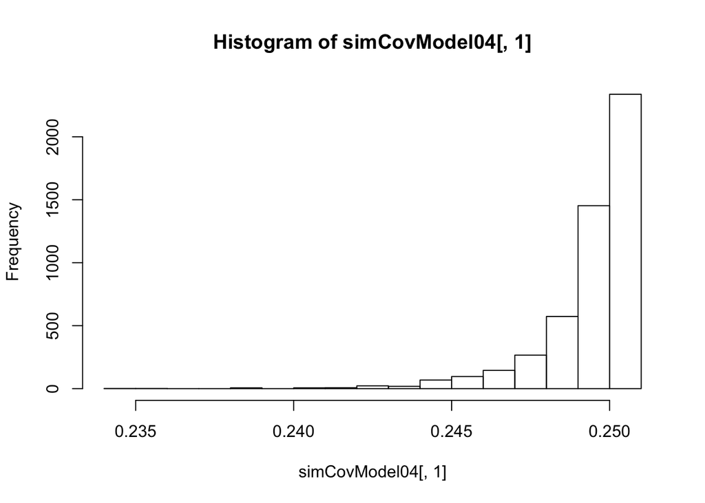

```r
# label values of simCor to ensure we have the right comparison
covNames = NULL
for (i in 1:ncol(simData)){
  for (j in 1:ncol(simData)){
    covNames = c(covNames, paste0("cov", i, "." , j))
  }
}
colnames(simCovModel04) = covNames

# show how one correlation compares to distribution of simulated correlations
dataCov = cov(FSdata)
hist(simCovModel04[,1])
```

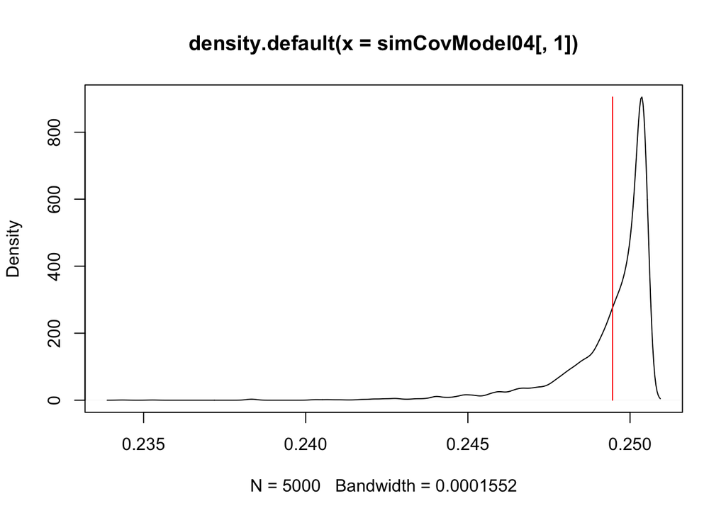

```r
plot(density(simCovModel04[,1]))
lines(x = c(dataCov[1,1], dataCov[1,1]), y = c(0, max(density(simCovModel04[,1])$y)), col = 2)
```

```r
quantile(simCovModel04[,1])
```

```
##        0%       25%       50%       75%      100%
## 0.2343423 0.2490724 0.2499651 0.2503417 0.2504673
```

```r
mean(simCovModel04[,1])
```

```
## [1] 0.2493762
```

```r
dataCov[1,1]
```

```
## [1] 0.2494595
```

```r
# create quantiles of correlations to see where each observed correlation falls
covQuantiles04 = NULL

# compute the quantiles of the observed correlations:

col = 1
for (i in 1:ncol(simData)){
  for (j in 1:ncol(simData)){
    # get empirical CDF of simulated correlation distribution
    covEcdf = ecdf(simCovModel04[,col])
    covQuantiles04 = rbind(covQuantiles04, c(i, j, summary(covEcdf), dataCov[i,j], covEcdf(dataCov[i,j])))

    col = col + 1
  }
}
colnames(covQuantiles04)[1:2] = c("Item 1", "Item 2")
colnames(covQuantiles04)[9:10] = c("ObsCor", "CorPctile")
covQuantiles04[which(covQuantiles04[,10] > .975 | covQuantiles04[,10] < .025),]
```

```
##      Item 1 Item 2         Min.    1st Qu.     Median       Mean
## [1,]      4      8 -0.000251081 0.03056825 0.03909367 0.03912274
## [2,]      7      8  0.015096248 0.04303424 0.05115079 0.05101411
## [3,]      8      4 -0.000251081 0.03056825 0.03909367 0.03912274
## [4,]      8      7  0.015096248 0.04303424 0.05115079 0.05101411
## [5,]      8     11  0.007480123 0.04349805 0.05200167 0.05194092
## [6,]      8     20  0.011159157 0.04133422 0.04880039 0.04889590
## [7,]     11      8  0.007480123 0.04349805 0.05200167 0.05194092
## [8,]     20      8  0.011159157 0.04133422 0.04880039 0.04889590
##         3rd Qu.       Max.     ObsCor CorPctile
## [1,] 0.04775160 0.07895801 0.10332334    1.0000
## [2,] 0.05895522 0.09000209 0.07831636    0.9952
## [3,] 0.04775160 0.07895801 0.10332334    1.0000
## [4,] 0.05895522 0.09000209 0.07831636    0.9952
## [5,] 0.06034489 0.09462966 0.07658669    0.9864
## [6,] 0.05672688 0.08525248 0.07082578    0.9846
## [7,] 0.06034489 0.09462966 0.07658669    0.9864
## [8,] 0.05672688 0.08525248 0.07082578    0.9846
```